# Extensions to the Grammar of Graphics

### position_nudge_line()

Function `position_nudge_line()` nudges away from a line, which can be a user supplied straight line as well as a smooth spline or a polynomial fitted to the observations themselves. The nudging is away and perpendicular to the local slope of the straight or curved line. It relies on the same assumptions as linear regression, assuming that *x* values are not subject to error. This in most cases prevents labels from overlaping a curve fitted to the data, even if not exactly based on the same model fit. When observations are sparse, this may be enough to obtain a nice arrangement of data labels.

```r
set.seed(16532)
df <- data.frame(
  x = -10:10,
  y = (-10:10)^2,
  yy = (-10:10)^2 + rnorm(21, 0, 4),
  yyy = (-10:10) + rnorm(21, 0, 4),
  l = letters[1:21]
)
```

The first, simple example shows that `position_nudge_line()` has shifted the direction of the nudging based on the alignment of the observations along a line. One could, of course, have in this case passed suitable values as arguments to *x* and *y* using `position_nudge()` from package ‘ggplot2’. However, `position_nudge_line()` will work without change irrespective of the slope or intercept along which the observations fall.

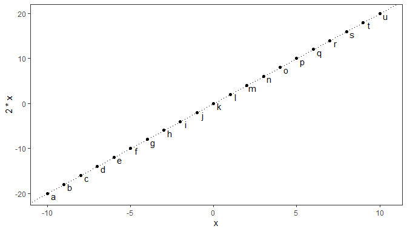

```r
ggplot(df, aes(x, 2 * x, label = l)) +
  geom_point() +
  geom_abline(intercept = 0, slope = 2, linetype = "dotted") +
  geom_text(position = position_nudge_line(x = -0.5, y = -0.8))
```

With observations with high variation in *y*, a linear model fit may need to be used. In this case fitted twice, once in `stat_smooth()` and once in `position_nudge_line()`.

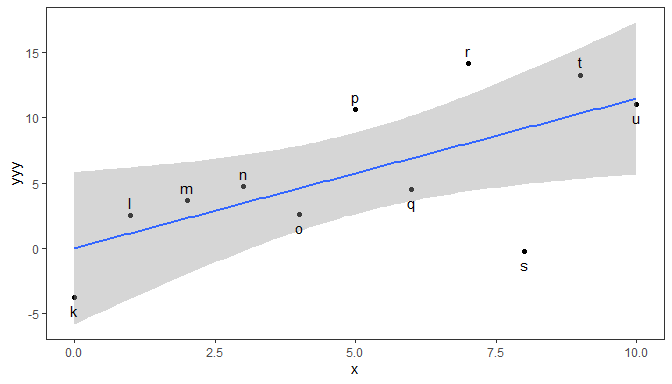

```r
ggplot(subset(df, x >= 0), aes(x, yyy)) +
  geom_point() +
  stat_smooth(method = "lm") +
  geom_text(aes(label = l),
            vjust = "center", hjust = "center",
            position = position_nudge_line(x = 0, y = 1.2,
                                           method = "lm",
                                           direction = "split"))
```

With lower variation in *y*, we can pass to `line_nudge` a multiplier to keep labels outside of the confidence band.

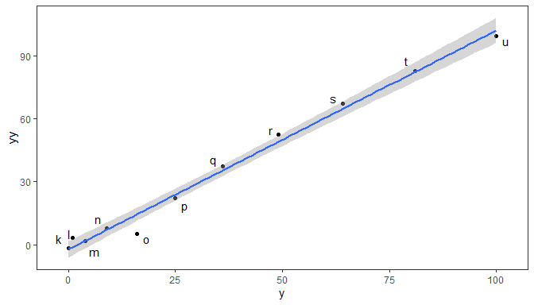

```r
ggplot(subset(df, x >= 0), aes(y, yy)) +
  geom_point() +
  stat_smooth(method = "lm", formula = y ~ x) +
  geom_text(aes(label = l),
            position = position_nudge_line(method = "lm",
                                           x = 3, y = 3,
                                           line_nudge = 2.5,
                                           direction = "split"))
```

If we want the nudging based on an arbitrary straight line not computed from `data`, we can pass the intercept and slope in a numeric vector of length two as an argument to parameter `abline`.

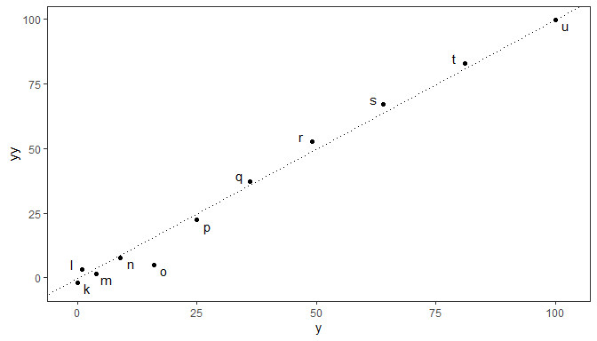

```r
ggplot(subset(df, x >= 0), aes(y, yy)) +
  geom_point() +
  geom_abline(intercept = 0, slope = 1, linetype = "dotted") +
  geom_text(aes(label = l),
            position = position_nudge_line(abline = c(0, 1),
                                           x = 3, y = 3,
                                           direction = "split"))
```

With observations that follow exactly a simple curve the defaults work well to automate the nudging of individual data labels away from the implicit curve. Positive values as arguments to `x` and `y` correspond to above and inside the curve. One could, of course, pass also in this case suitable values as arguments to *x* and *y* using `position_nudge()` from package ‘ggplot2’, but these arguments would need to be vectors with different *nudge* values for each observation.

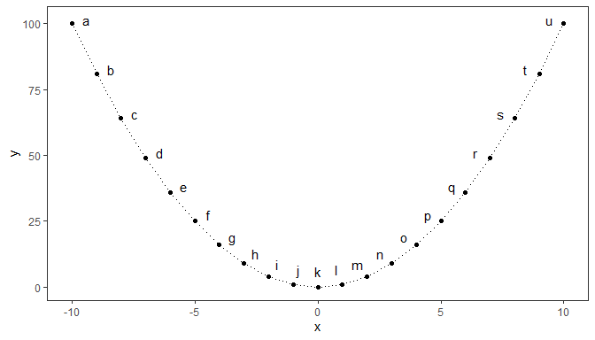

```r
ggplot(df, aes(x, y, label = l)) +
  geom_point() +
  geom_line(linetype = "dotted") +
  geom_text(position = position_nudge_line(x = 0.6, y = 6))
```

Negative values passed as arguments to `x` and `y` correspond to labels below and outside the curve.

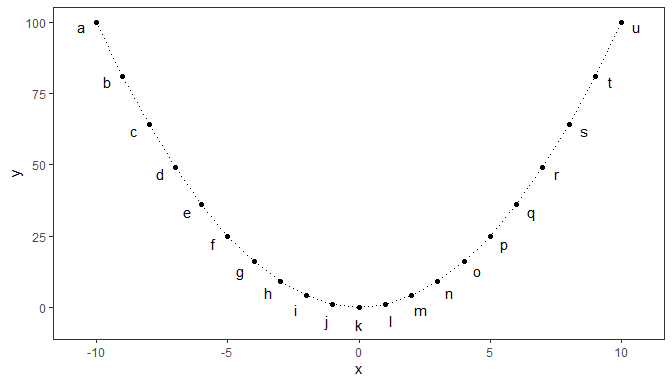

```r
ggplot(df, aes(x, y, label = l)) +
  geom_point() +
  geom_line(linetype = "dotted") +
  geom_text(position = position_nudge_line(x = -0.6, y = -6))
```

When the observations include random variation along *y*, it is important that the smoother used for the line added to a plot and that passed to `position_nudge_line()` are similar. By default `stat_smooth()` uses `"loess"` and `position_nudge_line()` with method `"spline"`, `smooth.sline()`, which are a good enough match.

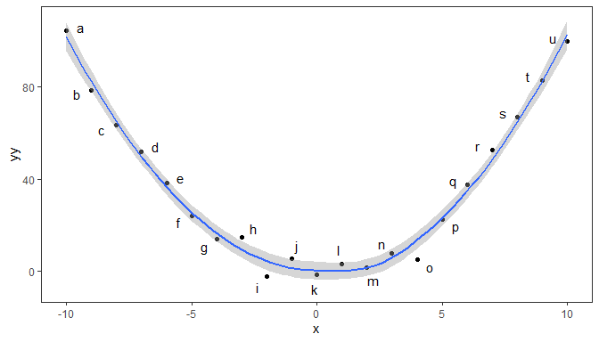

```r
ggplot(df, aes(x, yy, label = l)) +
  geom_point() +
  stat_smooth() +
  geom_text(aes(y = yy, label = l),
            position = position_nudge_line(x = 0.6,
                                           y = 6,
                                           direction = "split"))
```

We can use other geometries.

```r
ggplot(df, aes(x, yy, label = l)) +
  geom_point() +
  stat_smooth() +
  geom_label_repel(aes(y = yy, label = paste("point", l)),
            position = position_nudge_line(x = 0.6,
                                           y = 6,
                                           direction = "split"),
            min.segment.length = 0)
```

[output not shown]

When fitting a polynomial, `"lm"` should be the argument passed to `method` and a model formula preferably based on `poly()`, setting `raw = TRUE`, as argument to `formula`. *Currently no other methods are implemented in* `position_nudge_line()`.

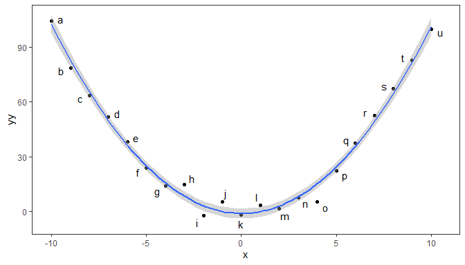

```r
ggplot(df, aes(x, yy, label = l)) +
  geom_point() +
  stat_smooth(method = "lm", formula = y ~ poly(x, 2, raw = TRUE)) +
  geom_text(aes(y = yy, label = l),
            position = position_nudge_line(method = "lm",
                                           x = 0.5,
                                           y = 5,
                                           formula = y ~ poly(x, 2, raw = TRUE),
                                           direction = "split"))
```

```r
ggplot(df, aes(x, yy, label = l)) +
  geom_point() +
  stat_smooth(method = "lm", formula = y ~ poly(x, 2, raw = TRUE)) +
  geom_text_repel(aes(y = yy, label = l),
                  box.padding = 0.5,
                  min.segment.length = Inf)
```

[output not shown]

```r
ggplot(df, aes(x, yy, label = l)) +
  geom_point() +
  stat_smooth() +
  geom_label_repel(aes(y = yy, label = paste("point", l)),
                  box.padding = 0.5,
                  min.segment.length = 0)
```

[output not shown]

Grouping is supported.

```r
df <- data.frame(x = rep(1:10, 2),
                 y = c(1:10, 10:1),
                 group = rep(c("a", "b"), c(10, 10)),
                 l = "+")
```

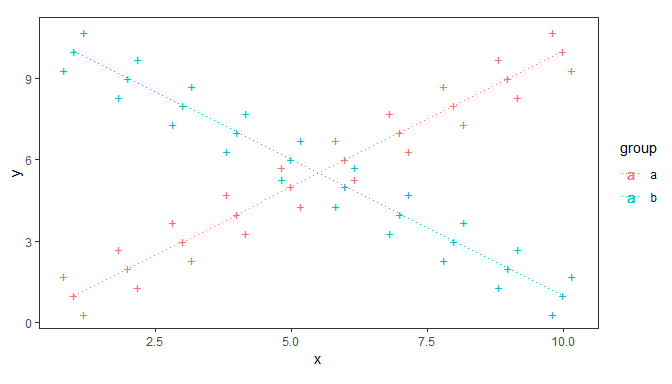

```r
ggplot(df, aes(x, y, label = l, color = group)) +
  geom_line(linetype = "dotted") +
  geom_text() +
  geom_text(position = position_nudge_line(x = 0.25, y = 1)) +
  geom_text(position = position_nudge_line(x = -0.25, y = -1)) +
  coord_equal(ratio = 0.5)
```

One needs to ensure that grouping is in effect in the geoms with nudging.

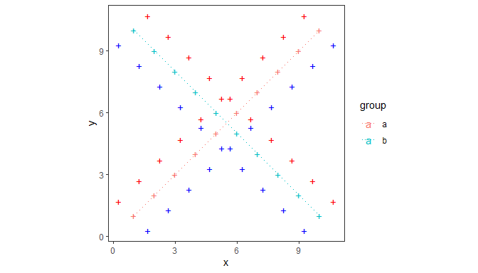

```r
ggplot(df, aes(x, y, label = l, color = group, group = group)) +
  geom_line(linetype = "dotted") +
  geom_text() +
  geom_text(color = "red",
            position = position_nudge_line(x = 1, y = 1)) +
  geom_text(color = "blue",
            position = position_nudge_line(x = -1, y = -1)) +
  coord_equal()
```

Facets are also supported.

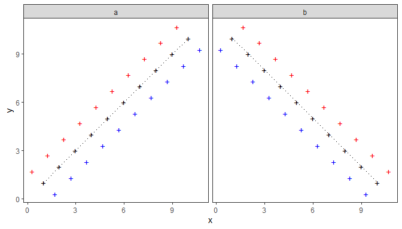

```r
ggplot(df, aes(x, y, label = l)) +
  geom_line(linetype = "dotted") +
  geom_text() +
  geom_text(position = position_nudge_line(x = 1, y = 1),
            color = "red") +
  geom_text(position = position_nudge_line(x = -1, y = -1),
            color = "blue") +
  facet_wrap(~group) +
  coord_equal(ratio = 1)
```

## Combined position functions

Nudging text or labels in a dodged or stacked bar or column plot has not been easy in ‘ggplot2’. This is a rather frequent situation, although usually there are workarounds. Non-the-less this imposed some limitations on the design of plots. The examples below show the use of *position* that implement the functionality of more than one of the position functions available in ‘ggplot2’. *Examples will be added here for the next release. Meanwhile, please, read the help page for each function. These pages contain examples.*

## Appendix A: More on density filtering

We define a function to simplify the generation of random data sets based on different probability distributions.

```r
make_data_tbl <- function(nrow = 100, rfun = rnorm, ...) {
  if (nrow %% 2) {
    nrow <- nrow + 1
  }

  set.seed(1001)

  tibble::tibble(
    x = rfun(nrow, ...),
    y = rfun(nrow, ...),
    group = rep(c("A", "B"), c(nrow / 2, nrow / 2))
  )
}
```

In all the examples in this vignette we use colors to demonstrate which data points are selected, but any other suitable aesthetic and discrete scale can be used instead. With `keep.sparse = FALSE` we keep 1/3 of the observations in the denser region of the plot. Although here we first plot all data points and later overplot the selected ones this is not necessary.

```r
ggplot(data = make_data_tbl(300), aes(x, y)) +
  geom_point() +
  stat_dens2d_filter(colour = "red",
                     keep.sparse = FALSE,
                     keep.fraction = 1/3)
```

[output not shown]

Here we highlight the observations split in three group equal groups, each of a different density of observations.

```r
ggplot(data = make_data_tbl(300), aes(x, y)) +
  geom_point() +
  stat_dens2d_filter(colour = "red",
                     keep.sparse = FALSE,
                     keep.fraction = 1/3)+
  stat_dens2d_filter(colour = "blue",
                     keep.fraction = 1/3)
```

[output not shown]

The algorithm seems to work well also with other distributions, in this example the uniform distribution.

```r
ggplot(data = make_data_tbl(300, rfun = runif), aes(x, y)) +
  geom_point() +
  stat_dens2d_filter(colour = "red", keep.fraction = 1/2)
```

[output not shown]

One example with the gamma distribution, which is asymmetric.

```r
ggplot(data = make_data_tbl(300, rfun = rgamma, shape = 2),
       aes(x, y)) +
  geom_point() +
  stat_dens2d_filter(colour = "red", keep.fraction = 1/3)
```

[output not shown]

## Appendix B: try_tibble()

### Time series

Several different formats for storing time series data are used in R. Here we use in the examples objects of class `ts` but several other classes are supported as `try.xts()` is used internally. The first example is a quarterly series.

```r
class(austres)
```

```
## [1] "ts"
```

```r
austres.df <- try_tibble(austres)
class(austres.df)
```

```
## [1] "tbl_df"     "tbl"        "data.frame"
```

```r
head(austres.df, 4)
```

```
## # A tibble: 4 x 2
##   time            x
##   <date>      <dbl>
## 1 1971-04-01 13067.
## 2 1971-07-01 13130.
## 3 1971-10-01 13198.
## 4 1972-01-01 13254.
```

The next chunk demonstrates that numeric times are expressed as decimal years in the returned data frame.

```r
austres.df <- try_tibble(austres, as.numeric = TRUE)
head(austres.df, 4)
```

```
## # A tibble: 4 x 2
##    time      x
##   <dbl>  <dbl>
## 1 1971. 13067.
## 2 1971. 13130.
## 3 1972. 13198.
## 4 1972  13254.
```

This second example is for a series of yearly values.

```r
class(lynx)
lynx.df <- try_tibble(lynx)
class(lynx.df)
head(lynx.df, 3)
```

[output not shown]

```r
lynx.df <- try_tibble(lynx, "year")
head(lynx.df, 3)
```

```
## # A tibble: 3 x 2
##   time           x
##   <date>     <dbl>
## 1 1822-01-01   269
## 2 1823-01-01   321
## 3 1824-01-01   585
```

```r
lynx_n.df <- try_tibble(lynx, "year", as.numeric = TRUE)
lapply(lynx_n.df, "class")
head(lynx_n.df, 3)
```

[output not shown]

### Other classes

`try_tibble()` attempts to handle gracefully objects that are not time series.

```r
try_tibble(1:5)
```

```r
try_tibble(letters[1:5])
```

```r
try_tibble(factor(letters[1:5]))
```

```r
try_tibble(list(x = rep(1,5), y = 1:5))
```

```r
try_tibble(data.frame(x = rep(1,5), y = 1:5))
```

```r
try_tibble(matrix(1:10, ncol = 2))
```